# COD_week2_1_MGK_BTE3207

Minsik Kim

2023-09-04

# Basic visualization of data

We are going to visualize this example dataset, SBP (systolic blood pressure) data from

https://nhiss.nhis.or.kr/bd/ab/bdabf003cv.do.

```r
dataset_sbp <- read.csv(file = "/Users/minsikkim/Dropbox (Personal)/Inha/5_Lectures/Advanced biostatistics/scripts/BTE3207_Advanced_Biostatistics/dataset/sbp_dataset_korea_2013-2014.csv")
```

## Summary statistics of data

We can use `mean()`, `sd()`, `median()` functions to calculate summary statistics.

```r
cat("#Mean of SBP of 1M subject\n",
      mean(dataset_sbp$SBP),
      "\n\n#Standard deviation of SBP of 1M subject\n",
      sd(dataset_sbp$SBP),
      "\n\n#Median of SBP of 1M subject\n",
      median(dataset_sbp$SBP)
      )
```

```
## #Mean of SBP of 1M subject
##  121.8718
##
## #Standard deviation of SBP of 1M subject
##  14.56171
##
## #Median of SBP of 1M subject
##  120
```

`cat()` function prints out the character. `\n` changes the line of the console.

Alternatively, `print()` can be used but the output of `print()` function is recognized as data in R. `cat()` just adds lines in the console.

## summary()

Instead, R has a convenient function called `summary()`.

```r
summary(dataset_sbp$SBP)
```

```
##    Min. 1st Qu.  Median    Mean 3rd Qu.    Max.
##    82.0   110.0   120.0   121.9   130.0   190.0
```

Voila! Now we can roughly see how the data looks like. However, it will be more straight forward if we can see the data in a form of figure.

## hist()

`hist()` function creates histogram in R. It as multiple arguments to make more informative histogram as output. For example,

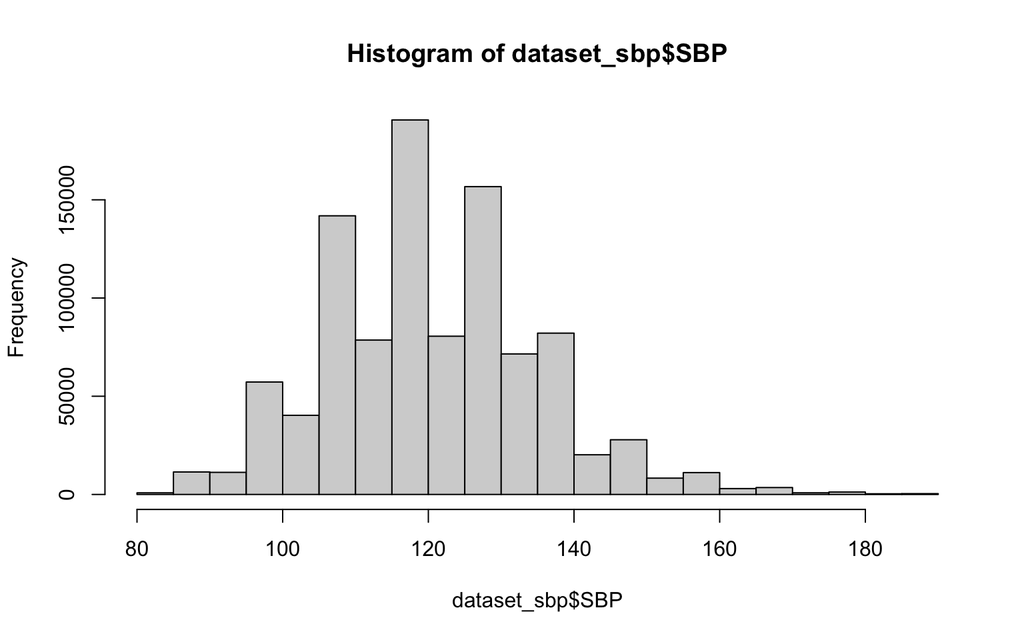

```r
hist(dataset_sbp$SBP)
```

## hist() - breaks

`hist()` as argument called `breaks =`, which can manually set the number of bars in the histogram.

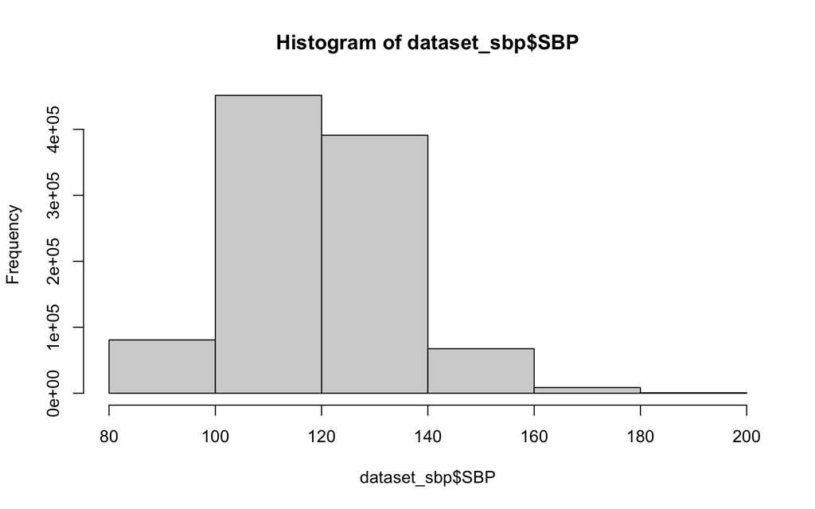

```r
hist(dataset_sbp$SBP,
     breaks = 5)
```

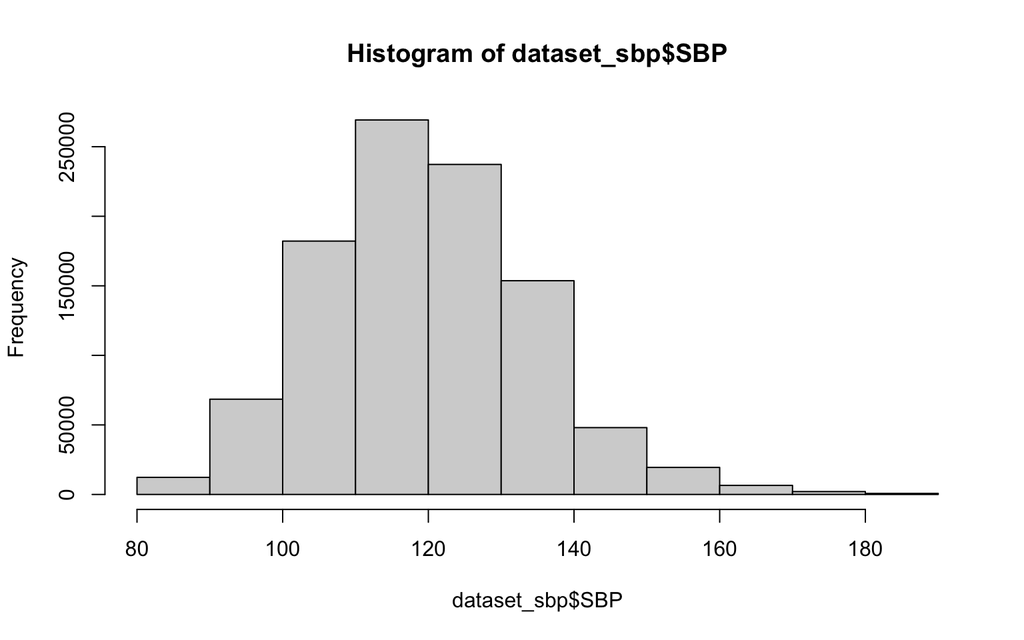

```r
hist(dataset_sbp$SBP,
     breaks = 10)
```

We can change number of bars by setting `breaks =` argument for `hist()` function.

## hist() - continued

By assigning `main =` (title of histogram), `xlab =` (x-axis label) and `ylab =` (y-axis label), we can create a histogram with more detailed information.

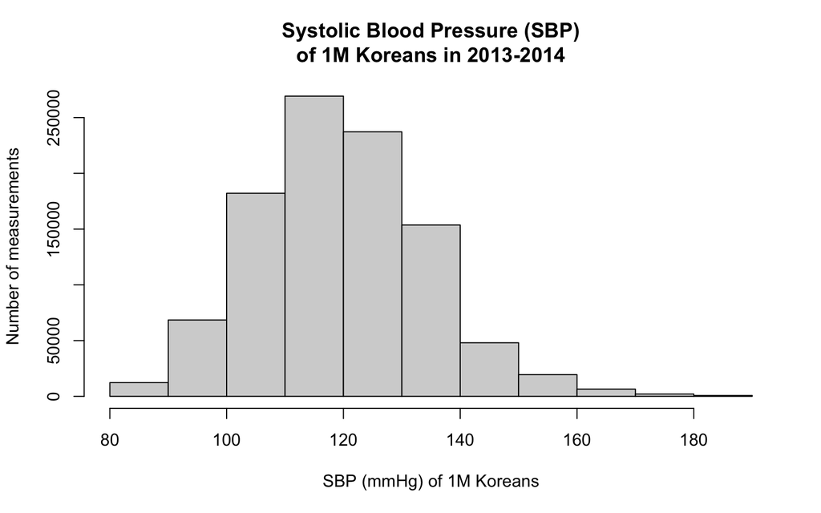

```r
hist(dataset_sbp$SBP,
     breaks = 10,
     main = "Systolic Blood Pressure (SBP)\nof 1M Koreans in 2013-2014",
     xlab = "SBP (mmHg) of 1M Koreans",
     ylab = "Number of measurements"
     )
```

## hist() - percentage

By imputing `density` variable of histogram, we can create a histogram with y axis that is having percentage.

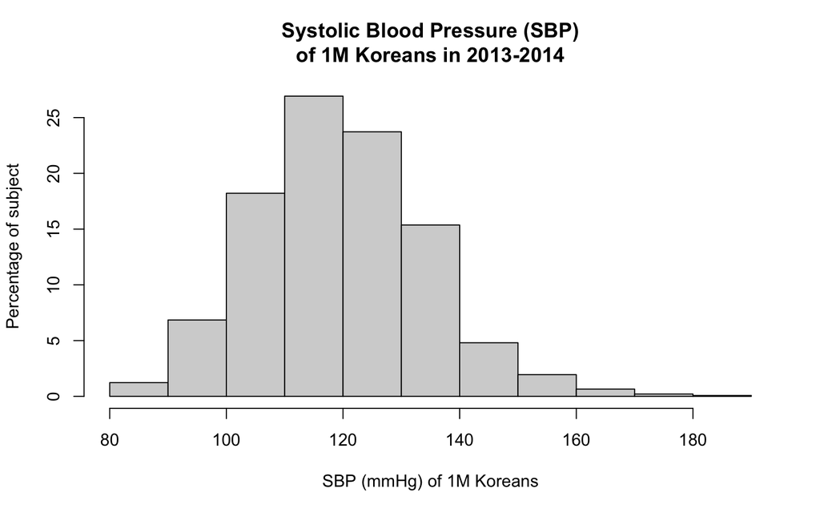

```r
h <- hist(dataset_sbp$SBP,
         breaks = 10,
         plot = F)

h$density <- h$counts/sum(h$counts)*100

plot(h,
     freq = FALSE,
     main = "Systolic Blood Pressure (SBP)\nof 1M Koreans in 2013-2014",
     xlab = "SBP (mmHg) of 1M Koreans",
     ylab = "Percentage of subject"
     )
```

# Boxplot

However, what should we do if we want to some summary statistic results as figures? Statisticians simply use boxplots. Boxplots can be generated by `boxplot()` command with information of what will be the x axis or colors.

## boxplot() - simple

We can directly put variable(vector) of our interest as `x`.

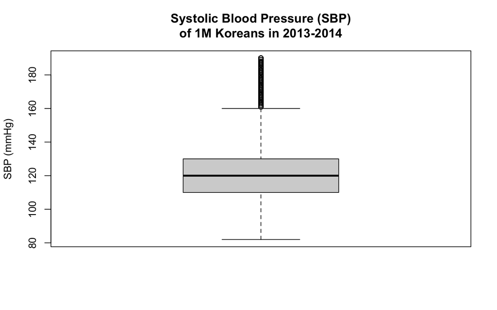

```r
boxplot(x = dataset_sbp$SBP,
        main = "Systolic Blood Pressure (SBP)\nof 1M Koreans in 2013-2014",
        ylab = "SBP (mmHg)"
        )
```

## boxplot() - with x axis

Boxplot is useful in comparing data, by adding more information along x-axis. To make more redundant boxplot, use `formula = y ~ x`. Here, `y` will be the variable of y-axis and x will be the x-axis.

**Remember x should be categorical (discrete) data.**

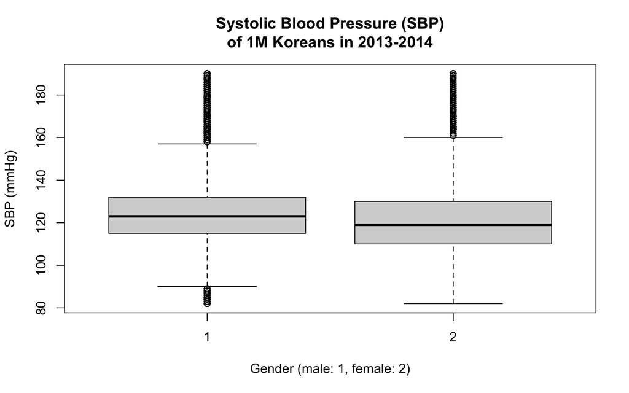

```r
boxplot(formula = SBP ~ SEX,
        data = dataset_sbp,
        main = "Systolic Blood Pressure (SBP)\nof 1M Koreans in 2013-2014",
        ylab = "SBP (mmHg)",
        xlab = "Gender (male: 1, female: 2)"
        )
```

## boxplot() - x-axis label

we can also change x-axis texts with `names =` argument.

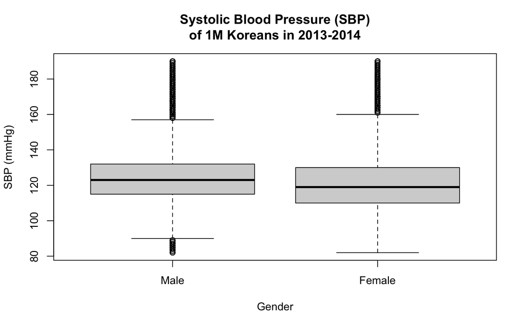

```r
boxplot(SBP ~ SEX,
        data = dataset_sbp,
        main = "Systolic Blood Pressure (SBP)\nof 1M Koreans in 2013-2014",
        ylab = "SBP (mmHg)",
        xlab = "Gender",
        names = c("Male",
                  "Female")
        )
```

# Question

It seems like the histogram of SBP is somewhat having multiple peaks in the data. Can you tell why?

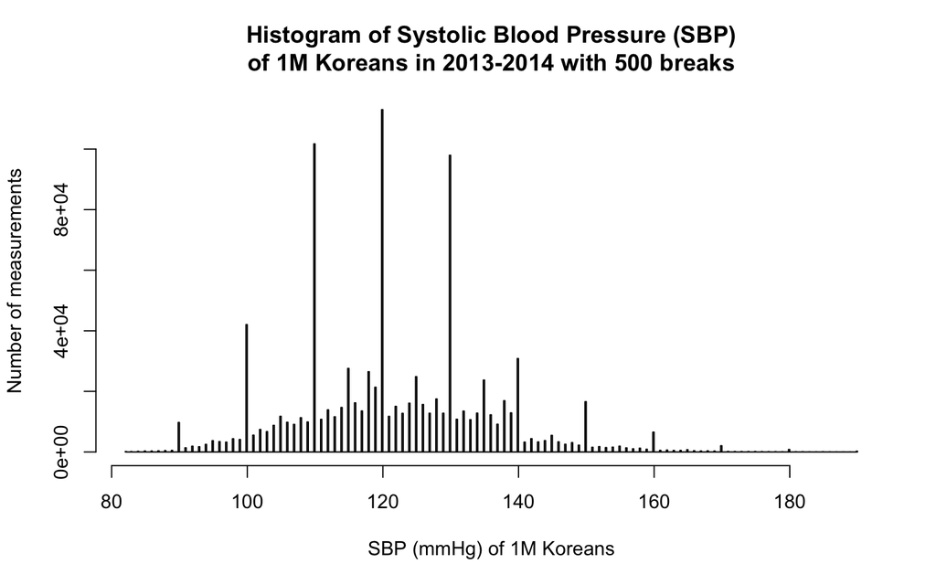

```r
hist(dataset_sbp$SBP,
     breaks = 500,
     main = "Histogram of Systolic Blood Pressure (SBP)\nof 1M Koreans in 2013-2014 with 500 breaks",
     xlab = "SBP (mmHg) of 1M Koreans",
     ylab = "Number of measurements"
     )
```

# Common distributions

## Symmetric & bell-shaped

[figure not shown]

```r
hist(dataset_sbp$SBP,
     breaks = 10,
     main = "Histogram of Systolic Blood Pressure (SBP)\nof 1M Koreans in 2013-2014 with 500 breaks",
     xlab = "SBP (mmHg) of 1M Koreans",
     ylab = "Number of measurements"
     )
```

## Right (positively) skewed

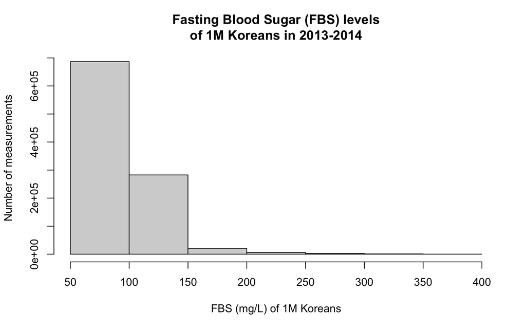

```r
hist(dataset_sbp$FBS,
     breaks = 10,
     main = "Fasting Blood Sugar (FBS) levels\nof 1M Koreans in 2013-2014",
     xlab = "FBS (mg/L) of 1M Koreans",
     ylab = "Number of measurements"
     )
```

## Left (negatively skewed)

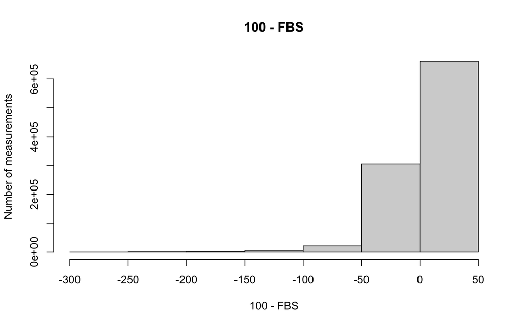

```r
hist(100-dataset_sbp$FBS,
     breaks = 10,
     main = "100 - FBS",
     xlab = "100 - FBS",
     ylab = "Number of measurements"
     )
```

## Uniform distributions

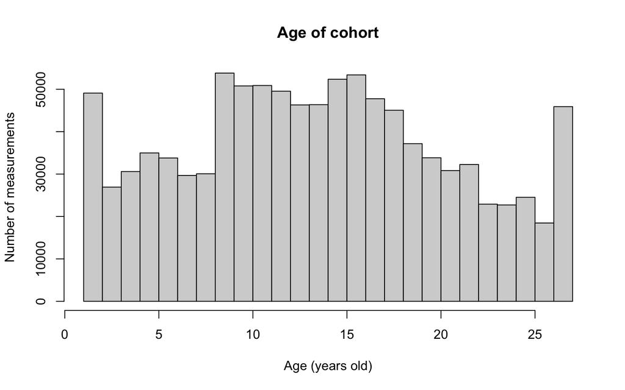

```r
hist(dataset_sbp$BTH_G,
     breaks = 30,
     main = "Age of cohort",
     xlab = "Age (years old)",
     ylab = "Number of measurements"
     )
```

# Bibliography

[output not shown]